# 全国新型冠状病毒疫情预测分析

狗熊会

案例难度：**

这个案例的学习目标包括：

（1）了解全国疫情数据，学习基于原始字段构建增长率指标；

（2）学习对数值型变量进行基本的描述性分析，并尝试探索因变量与各解释变量的关系

（3）学习构建线性回归模型，并实现每日新增确诊人数的一步预测。

## 准备工作

```r
# 清除工作环境
cat("\014");rm(list=ls())
```

## 任务一：读取数据

找到数据“全国新冠病毒数据.csv”。读入样本数据（提前设置好工作路径），命名为a。用summary函数查看数据中包含各个变量的基本情况。

```r
# 读取数据
a <- read.csv("全国新冠病毒数据.csv")
summary(a)
```

```
##       日期       新增确诊       累计确诊        现有重症
##  1月23日: 1   Min.   : 259   Min.   :  830   Min.   :  177
##  1月24日: 1   1st Qu.: 678   1st Qu.:13733   1st Qu.: 2031
##  1月25日: 1   Median :1760   Median :41404   Median : 6908
##  1月26日: 1   Mean   :1699   Mean   :41354   Mean   : 6291
##  1月27日: 1   3rd Qu.:2506   3rd Qu.:74389   3rd Qu.:10314
##  1月28日: 1   Max.   :3887   Max.   :78824   Max.   :11977
##  (Other):30
##     累计死亡         累计治愈        累计密切接触    正在接受医学观察
##  Min.   :  25.0   Min.   :   34.0   Min.   :  9507   Min.   :  8420
##  1st Qu.: 292.8   1st Qu.:  306.8   1st Qu.:157130   1st Qu.: 81237
##  Median : 962.0   Median : 3638.5   Median :413962   Median :131122
##  Mean   :1179.1   Mean   : 8829.4   Mean   :369941   Mean   :122828
##  3rd Qu.:2032.5   3rd Qu.:14821.2   3rd Qu.:578104   3rd Qu.:178834
##  Max.   :2788.0   Max.   :36117.0   Max.   :656054   Max.   :189660
##
##   新增密切接触
##  Min.   : 3610
##  1st Qu.: 9544
##  Median :17289
##  Mean   :18060
##  3rd Qu.:25906
##  Max.   :31470
##
```

## 任务二：绘制原始数据的点线图

原始数据中各个变量均为数值型，并且是时间序列数据。因此，想要各个变量的分布和走势有个直观的了解，点线图是很好的方法。请按照下列要求绘制四幅点线图：

（1）在这场疫情中，每天的新增人数的走势直观地反映了疫情的严重程度，无疑是最让人关心的，因此可以单独绘制该变量的点线图

（2）一些累计指标，累计确诊、累计死亡与累计治愈可以放在一起绘制，更方便进行对比观察

（3）现有重症人数一定程度上反映了未来的死亡状况，可以单独绘制

（4）与潜在感染人群相关的指标，如累计密切接触、正在接受医学观察、新增密切接触人数，可以放在一起绘制

在绘图时，你可以用par函数来设置画布上图片的排列方式，用plot函数和points函数来绘制点线图，用axis函数设置横轴并用legend函数设置图例。

最后，通过几幅点线图，尝试对新冠疫情的发展趋势进行解读。

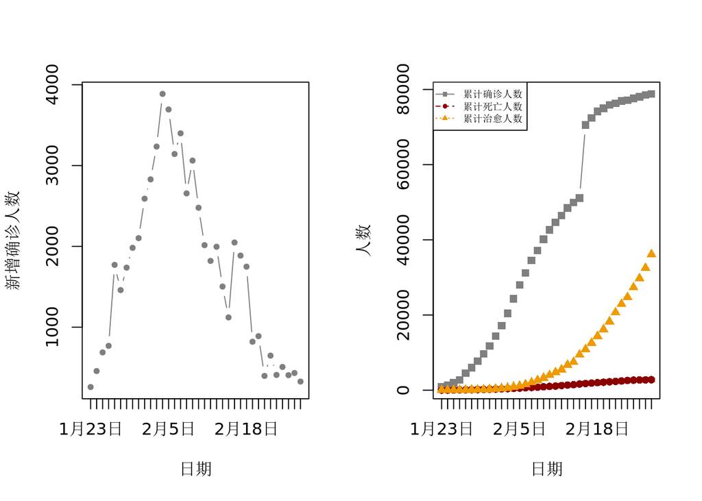

```r
n=length(a[,1])
x=c(1:n)

# 设置画布，图片将以1x2格式排列
par(mfrow=c(1,2))

# 绘制新增人数走势图
plot(x,a$新增确诊,type="b",xlab="日期",ylab="新增确诊人数",pch=20,col="gray50",lty=1,xaxt="n")
axis(1,x,labels=a$日期)

# 绘制累计确诊、累计死亡与累计治愈走势图
plot(x,a$累计确诊,type="b",xlab="日期",ylab="人数",pch=15,col="gray50",lty=1,xaxt="n")
points(x,a$累计死亡,type="b",pch=16,col='darkred',lty=2)
points(x,a$累计治愈,type="b",pch=17,col='orange2',lty=3)
axis(1,x,labels=a$日期) # 设置横轴
legend('topleft',cex=0.6, c("累计确诊人数","累计死亡人数","累计治愈人数"),pch=c(15,16,17),col=c("gray50","darkred","orange2"),lty=c(1,2,3)) # 设置图例
```

[figure not shown]

```r
# 绘制现有重症人数走势图
plot(x,a$现有重症,type="b",xlab="日期",ylab="现有重症人数",pch=20,col="gray50",lty=1,xaxt="n")
axis(1,x,labels=a$日期) # 设置横轴

# 绘制累计密切接触、正在接受医学观察、新增密切接触人数走势图
plot(x,a$累计密切接触/10000,type="b",xlab="日期",ylab="人数（万人）",pch=15,col="gray50",lty=1,xaxt="n")
points(x,a$新增密切接触/10000,type="b",pch=16,col='darkred',lty=2)
points(x,a$正在接受医学观察/10000,type="b",pch=17,col='orange2',lty=3)
axis(1,x,labels=a$日期) # 设置横轴
legend('topleft',cex=0.6, c("累计密切接触诊人数","正在医学观察人数","新增密切接触人数"),pch=c(15,16,17),col=c("gray50","darkred","orange2"),lty=c(1,2,3)) # 设置图例
```

## 任务三：计算增长率指标

增长率指标的大小能够反映疫情发展的严重程度，因此进一步对原始数据中的8个变量计算增长率指标。以“新增确诊增长率”为例，计算公式如下：

t+1日新增确诊增长率=100%*（t+1日新增确诊/t日新增确诊人数-1）

在计算时，你可以用diff函数对某个变量进行错位相减。最后，以“新增确诊增长率”和“现有重症增长率”为例，绘制两个指标的点线图，并尝试解读。

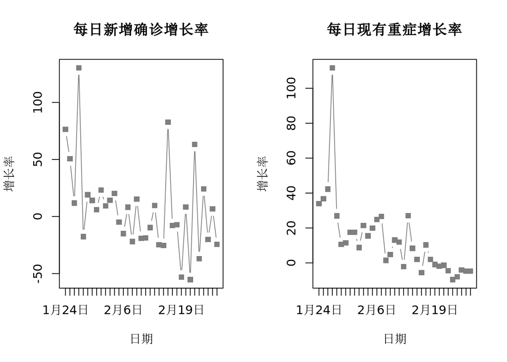

```r
# 计算增长率指标
新增确诊增长率= 100*(diff(a$新增确诊)/a$新增确诊[-n])
累计确诊增长率=100*(diff(a$累计确诊)/a$累计确诊[-n])
现有重症增长率=100*(diff(a$现有重症)/a$现有重症[-n])
累计死亡增长率=100*(diff(a$累计死亡)/a$累计死亡[-n])
累计治愈增长率=100*(diff(a$累计治愈)/a$累计治愈[-n])
累计密切接触增长率=100*(diff(a$累计密切接触)/a$累计密切接触[-n])
正在接受医学观察增长率=100*(diff(a$正在接受医学观察)/a$正在接受医学观察[-n])
新增密切接触增长率=100*(diff(a$新增密切接触)/a$新增密切接触[-n])
DATA=as.data.frame(cbind(新增确诊增长率,累计确诊增长率,现有重症增长率,累计死亡增长率,累计治愈增长率,累计密切接触增长率,正在接受医学观察增长率,新增密切接触增长率))

# 计算增长率指标
n=length(a[,1])-1
x=c(1:n)
par(mfrow=c(1,2))
plot(x,新增确诊增长率,type="b",main="每日新增确诊增长率",xlab="日期",ylab="增长率",pch=15,col="gray50",lty=1,xaxt="n")
axis(1,x,labels=a$日期[-1]) # 设置横轴
plot(x,现有重症增长率,type="b",main="每日现有重症增长率",xlab="日期",ylab="增长率",pch=15,col="gray50",lty=1,xaxt="n")
axis(1,x,labels=a$日期[-1]) # 设置横轴
```

##### 解读参考：

新增确诊人数增长率反映了当日新增确诊人数的增长情况，重症现有增长率反映了现存患有新冠重症病人的增长情况，可以看到这两个指标都呈下降趋势，说明疫情得到了有效控制

## 任务四：探索各变量与“新增确诊增长率”的关系

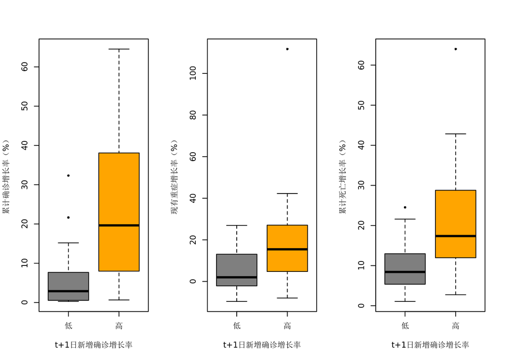

```r
# 将因变量分组
cat=as.factor(新增确诊增长率>median(新增确诊增长率)) # 因子化数据
levels(cat)=c("低","高") # 设置因子水平
cat=as.factor(新增确诊增长率>median(新增确诊增长率)) # 因子化数据
levels(cat)=c("低","高") # 设置因子水平

#绘制箱线图
par(mfrow=c(1,3)) #设置画布
boxplot(累计确诊增长率~cat,ylab="累计确诊增长率（%）",xlab="t+1日新增确诊增长率", col=c('gray50', 'orange'), pch=16)
boxplot(现有重症增长率~cat,ylab="现有重症增长率（%）",xlab="t+1日新增确诊增长率",  col=c('gray50', 'orange'), pch=16)
boxplot(累计死亡增长率~cat,ylab="累计死亡增长率（%）",xlab="t+1日新增确诊增长率", col=c('gray50', 'orange'), pch=16)
```

##### 解读：

（1）累计确诊增长率在因变量的高低两组之间分布差异比较明显，这说明累积确诊增长率和新增确诊增长率保持了较为一致的变化趋势。

（2）现有重症增长率、累积死亡增长率在t+1日新增确诊增长率较高的组别中相应的取值也较高，现有重症增长率和累计死亡增长率均反映了疫情的严峻性，这两个变量取值较高则代表了新冠疫情处于高发期，因此新增确诊人数也可能走高。

## 任务五：建立模型

```r
# 建立全模型
fit=lm(新增确诊增长率~累计确诊增长率+现有重症增长率+累计死亡增长率+累计治愈增长率+累计密切接触增长率+正在接受医学观察增长率+新增密切接触增长率,data=DATA)
# 使用AIC进行变量选择
model.aic=step(fit,trace=F)
# 查看回归系数
summary(model.aic)
```

```
##
## Call:
## lm(formula = 新增确诊增长率 ~ 累计确诊增长率 +
##     累计治愈增长率 + 累计密切接触增长率, data = DATA)
##
## Residuals:
##     Min      1Q  Median      3Q     Max
## -40.913 -12.057  -0.447  12.083  74.577
##
## Coefficients:
##                    Estimate Std. Error t value Pr(>|t|)
## (Intercept)         -6.1195     7.7387  -0.791   0.4351
## 累计确诊增长率       3.0825     0.5617   5.488  5.3e-06 ***
## 累计治愈增长率      -0.4955     0.2967  -1.670   0.1049
## 累计密切接触增长率  -1.6144     0.6084  -2.653   0.0125 *
## ---
## Signif. codes:  0 '***' 0.001 '**' 0.01 '*' 0.05 '.' 0.1 ' ' 1
##
## Residual standard error: 23.04 on 31 degrees of freedom
## Multiple R-squared:  0.6656, Adjusted R-squared:  0.6332
## F-statistic: 20.57 on 3 and 31 DF,  p-value: 1.592e-07
```

##### 解读参考：

（1） 在95%的置信度水平下，t日累计确诊增长率对因变量具有显著的正向影响。具体来说，在控制住其他变量不变的情况下，累计确诊增长率每增加1个单位，t+1日新增确诊增长率平均增加3.083个单位。累计确诊增长率代表着过去一段时间内确诊人数累计值的增长情况，累计确诊增长率越高，形势越严峻，因此下一日新增确诊增长率也可能走高。

（2） 在95%的置信度水平下，t日累计密切接触增长率对因变量具有显著的负向影响。具体来说，在控制住其他变量不变的情况下，累计密切接触增长率每增加1个单位，t+1日新增确诊增长率平均降低1.614个单位。在控制了其他变量的影响后，累积密切接触增长率对新增确诊增长率的负向影响，其实恰恰表现了我国疫情防控措施的有效性。密切接触者人群范围的扩大是对疑似病例进行全面追踪的结果，它也间接对易感人群形成保护，因此在全国范围内都出现了疑似转确诊比例、密切接触转确诊比例呈下降趋势的现象，这对未来的疫情防控将起到积极作用。

## 任务六：模型预测

基于本案例的AIC模型，可以使用predict函数实现对未来一天的新增确诊增长率进行预测的目的。本案例建模的数据截止到2月27日，因此尝试采用该模型对2月28日的新增确诊增长率进行预测。预测时可以使用predict函数，并且可以通过设置interval = “confidence”得到预测值95%的置信区间。得到“新增确诊增长率”的预测值之后，可以进一步转换成“新增确诊人数”的预测值。已知2月28日真实的新增确诊人数为427，看看你的预测结果和真实结果差异如何？

```r
# 得到2月27日的数据
pred = DATA[n,]
# 计算新增确诊增长率的预测值和置信区间
ratio = predict(model.aic, pred, interval = "confidence")
# 转成新增确诊人数
count=ratio*0.01*as.vector(a$新增确诊[n]) + as.vector(a$新增确诊[n])
print(count)
```

```
##         fit     lwr      upr
## 35 383.9868 333.723 434.2507
```

##### 解读参考：

可以看到，真实值位于置信区间以内，这说明AIC模型可以对未来一天的新增确诊人数进行较为精准的预测